# Project 2 – Classification (Stat897D - Fall 2015)

by Xiang Wang on November 9, 2015

#### Background

Gene Expression Data and Physical Interaction Network (Brem and Kruglyak, 2005): Time course data reflect the changes in expression levels in response to *Rapamycin*. The original data source forms a 231 × 95 × 6 array: 231 active genes; 95 segregants (individuals); 6 time points for each segregant at time 0, 10, 20, 30, 40, 50 mins (i.e., 95 x 6 = 570 total expression measurements for each gene). Proteins are involved in most cell functions and they typically bind together to form complex structures. Protein-protein interactions (PPI) are highly important for almost all biological processes. Gene expression data measure the mRNA levels that approximate states of a complex biological system. PPI data is widely used to predict interactions among gene expression data.

**Goal**: Identify interacted genes by using the provided gene expression data. The entire dataset has been split into 2 parts: Training data: 122 genes; Validation data: 53 genes. The data is available in R workspace “Project2.RData” (available in Angel). First, load the data:

```r
load("Project2.RData")
ls()
```

```
## [1] "DATA.train"    "DATA.valid"    "Network.train" "Network.valid"
```

- Network.train: 122 × 122 matrix showing the PPI network (0 if not interacted, 1 if interacted);
- Network.valid: 53 × 53 matrix showing the PPI network for the validation data;
- DATA.train: 122 × 570 gene expression matrix;
- DATA.valid: 53 × 570 gene expression matrix for the validation data. Next, put the PPI networks into vectors with each element being a gene pair:

```r
Y.train <- Network.train[lower.tri(Network.train)]
n.train <- length(Y.train) # 7381 pairs in training # data
Y.train.mean <- mean(Y.train) # 0.02669, proportion of PPI interactions in training data
Y.valid <- Network.valid[lower.tri(Network.valid)]
n.valid <- length(Y.valid) # 1378 pairs in validation # data
mean(Y.valid) # 0.0312 proportion of PPI interactions in validation data
```

```
## [1] 0.03120464
```

Next, to predict the interaction between gene i and gene j, we’ll use 5 predictors: mean of gene i (across the 570 measurements for that gene), variance of gene i; mean of gene j, variance of gene j; covariance between gene i and gene j:

```r
X.train = NULL # 7381 by 5 matrix with 5 predictors for each gene pair
for (i in 1:(dim(DATA.train)[1]-1))
  for (j in (i+1):dim(DATA.train)[1])
    X.train = rbind(X.train,
                    c(mean(DATA.train[i,]), mean(DATA.train[j,]),
                      cov(DATA.train[i,],DATA.train[j,]),
                      var(DATA.train[i,]), var(DATA.train[j,])))
data.train <- as.data.frame(cbind(Y.train, X.train))
names(data.train) <- c("Y", "X1", "X2", "X3", "X4", "X5")

X.valid = NULL # 1378 by 5 matrix with 5 predictors for each gene pair
for (i in 1:(dim(DATA.valid)[1]-1))
  for (j in (i+1):dim(DATA.valid)[1])
    X.valid = rbind(X.valid,
                    c(mean(DATA.valid[i,]), mean(DATA.valid[j,]),
                      cov(DATA.valid[i,],DATA.valid[j,]), var(DATA.valid[i,]),
                      var(DATA.valid[j,])))
data.valid <- as.data.frame(X.valid)
names(data.valid) <- c("X1", "X2", "X3", "X4", "X5")
```

Fit the following models to the training data using the data frame, data.train, that contains Y as the response variable and {X1, X2, X3, X4, X5} as the predictors. For each model obtain the posterior probabilities of interaction for the 7381 gene pairs in the training data, and classify them into class 1 (interacted) if they are in the top 200 most likely interacted pairs and into class 0 (not interacted) otherwise (see hint 2 below). Use these classification results and Y.train to calculate the training classification error rate, sensitivity, and specificity for each model.

##### Model a: Logistic regression analysis using glm function

```r
model.logistic <- glm(Y ~ X1+X2+X3+X4+X5, data.train, family=binomial("logit"))
summary(model.logistic)
```

```
##
## Call:
## glm(formula = Y ~ X1 + X2 + X3 + X4 + X5, family = binomial("logit"),
##     data = data.train)
##
## Deviance Residuals:
##     Min       1Q   Median       3Q      Max
## -1.2821  -0.2354  -0.1453  -0.0863   3.7638
##
## Coefficients:
##               Estimate Std. Error z value Pr(>|z|)
## (Intercept) -14.123839   0.903543 -15.632  < 2e-16 ***
## X1            0.494346   0.051149   9.665  < 2e-16 ***
## X2            0.403708   0.048423   8.337  < 2e-16 ***
## X3            1.435135   0.197449   7.268 3.64e-13 ***
## X4            0.001906   0.094916   0.020    0.984
## X5           -0.083625   0.096594  -0.866    0.387
## ---
## Signif. codes:  0 '***' 0.001 '**' 0.01 '*' 0.05 '.' 0.1 ' ' 1
##
## (Dispersion parameter for binomial family taken to be 1)
##
##     Null deviance: 1816.3  on 7380  degrees of freedom
## Residual deviance: 1507.3  on 7375  degrees of freedom
## AIC: 1519.3
##
## Number of Fisher Scoring iterations: 7
```

```r
# Coefficients:
#             Estimate Std. Error z value Pr(>|z|)
#(Intercept) -14.123839   0.903543 -15.632  < 2e-16 ***
#X1            0.494346   0.051149   9.665  < 2e-16 ***
#X2            0.403708   0.048423   8.337  < 2e-16 ***
#X3            1.435135   0.197449   7.268 3.64e-13 ***
#X4            0.001906   0.094916   0.020    0.984
#X5           -0.083625   0.096594  -0.866    0.387
#---
#Signif. codes:  0 ‘***’ 0.001 ‘**’ 0.01 ‘*’ 0.05 ‘.’ 0.1 ‘ ’ 1
#(Dispersion parameter for binomial family taken to be 1)
#
#    Null deviance: 1816.3  on 7380  degrees of freedom
#Residual deviance: 1507.3  on 7375  degrees of freedom
#AIC: 1519.3
#Number of Fisher Scoring iterations: 7

post.train.logistic <- model.logistic$fitted.values # n.train posterior probabilities of Y=1
Ghat.train.logistic <- ifelse(post.train.logistic > sort(post.train.logistic, decreasing=T)[201],1,0) # classification rule
table(Ghat.train.logistic,Y.train) # classification table
```

```
##                    Y.train
## Ghat.train.logistic    0    1
##                   0 7062  119
##                   1  122   78
```

```r
#                     Y.train
#Ghat.train.logistic    0    1
#                  0 7062  119
#                  1  122   78
sum(abs(Ghat.train.logistic-Y.train))/n.train # training data classification error rate = (122+119)/7381 = 0.033
```

```
## [1] 0.0326514
```

```r
sum(Ghat.train.logistic==1&Y.train==1)/sum(Y.train==1) # sensitivity = 78/(119+78) = 0.396
```

```
## [1] 0.3959391
```

```r
sum(Ghat.train.logistic==0&Y.train==0)/sum(Y.train==0) # specificity = 7062/(7062+122) = 0.983
```

```
## [1] 0.9830178
```

```r
post.valid.logistic <- predict(model.logistic, data.valid, type="response") # n.valid post probs
Ghat.valid.logistic <- ifelse(post.valid.logistic > sort(post.valid.logistic, decreasing=T)[201],1,0) # use same probability cutoff
table(Ghat.valid.logistic,Y.valid) # classification table
```

```
##                    Y.valid
## Ghat.valid.logistic    0    1
##                   0 1160   18
##                   1  175   25
```

```r
#                   Y.valid
#Ghat.valid.logistic    0    1
#                  0 1160   18
#                  1  175   25
sum(abs(Ghat.valid.logistic-Y.valid))/n.valid # classification error rate = (175+18)/1378 = 0.140
```

```
## [1] 0.1400581
```

```r
sum(Ghat.valid.logistic==1&Y.valid==1)/sum(Y.valid==1) # sensitivity = 25/(25+18) = 0.581
```

```
## [1] 0.5813953
```

```r
sum(Ghat.valid.logistic==0&Y.valid==0)/sum(Y.valid==0) # specificity = 1160/(175+1160) = 0.869
```

```
## [1] 0.8689139
```

##### Model b: Linear discriminant analysis using lda function in MASS

```r
library(MASS)
model.lda <- lda(Y ~ X1+X2+X3+X4+X5, data.train); model.lda
```

```
## Call:
## lda(Y ~ X1 + X2 + X3 + X4 + X5, data = data.train)
##
## Prior probabilities of groups:
##          0          1
## 0.97330985 0.02669015
##
## Group means:
##         X1       X2         X3        X4        X5
## 0 10.67300 10.80075 0.01331963 0.8531054 0.9114245
## 1 12.26554 12.22904 0.27908714 0.7315978 0.6442998
##
## Coefficients of linear discriminants:
##           LD1
## X1 0.35181460
## X2 0.29353120
## X3 1.03316558
## X4 0.08062700
## X5 0.04478497
```

```r
#Prior probabilities of groups:
#         0          1
#0.97330985 0.02669015
#
#Group means:
#        X1       X2         X3        X4        X5
#0 10.67300 10.80075 0.01331963 0.8531054 0.9114245
#1 12.26554 12.22904 0.27908714 0.7315978 0.6442998
#
#Coefficients of linear discriminants:
#          LD1
#X1 0.35181460
#X2 0.29353120
#X3 1.03316558
#X4 0.08062700
#X5 0.04478497

# Note that these coefficients differ slightly from the hand calculation due to the particular method that the lda function uses; also no coefficient provided for the intercept, so it is not possible to use these results alone to add the linear classification boundary to a plot

post.train.lda <- predict(model.lda)$posterior[,2] # n.train posterior probabilities of Y=1
Ghat.train.lda <- ifelse(post.train.lda > sort(post.train.lda, decreasing=T)[201],1,0) # classification rule
table(Ghat.train.lda,Y.train) # classification table
```

```
##               Y.train
## Ghat.train.lda    0    1
##              0 7051  130
##              1  133   67
```

```r
#              Y.train
#Ghat.train.lda    0    1
#             0 7051  130
#             1  133   67
sum(abs(Ghat.train.lda-Y.train))/n.train # training data classification error rate = (133+130)/7381 = 0.036
```

```
## [1] 0.03563203
```

```r
sum(Ghat.train.lda==1&Y.train==1)/sum(Y.train==1) # sensitivity = 67/(130+67) = 0.340
```

```
## [1] 0.3401015
```

```r
sum(Ghat.train.lda==0&Y.train==0)/sum(Y.train==0) # specificity = 7051/(7051+133) = 0.981
```

```
## [1] 0.9814866
```

```r
# Suppose we had validation data
post.valid.lda <- predict(model.lda, data.valid)$posterior[,2] # n.valid posterior probabilities of Y=1
Ghat.valid.lda <- ifelse(post.valid.lda > sort(post.valid.lda, decreasing=T)[201],1,0) # use same probability cutoff
table(Ghat.valid.lda,Y.valid) # classification table
```

```
##               Y.valid
## Ghat.valid.lda    0    1
##              0 1160   18
##              1  175   25
```

```r
#              Y.valid
#Ghat.valid.lda    0    1
#             0 1160   18
#             1  175   25
sum(abs(Ghat.valid.lda-Y.valid))/n.valid # classification error rate = (175+18)/1378 = 0.140
```

```
## [1] 0.1400581
```

```r
sum(Ghat.valid.lda==1&Y.valid==1)/sum(Y.valid==1) # sensitivity = 25/(25+18) = 0.581
```

```
## [1] 0.5813953
```

```r
sum(Ghat.valid.lda==0&Y.valid==0)/sum(Y.valid==0) # specificity = 1160/(1160+175) = 0.869
```

```
## [1] 0.8689139
```

##### Model c: Quadratic discriminant analysis using qda function in MASS

```r
model.qda <- qda(Y ~ X1+X2+X3+X4+X5, data.train); model.qda
```

```
## Call:
## qda(Y ~ X1 + X2 + X3 + X4 + X5, data = data.train)
##
## Prior probabilities of groups:
##          0          1
## 0.97330985 0.02669015
##
## Group means:
##         X1       X2         X3        X4        X5
## 0 10.67300 10.80075 0.01331963 0.8531054 0.9114245
## 1 12.26554 12.22904 0.27908714 0.7315978 0.6442998
```

```r
#Prior probabilities of groups:
#         0          1
#0.97330985 0.02669015
#
#Group means:
#        X1       X2         X3        X4        X5
#0 10.67300 10.80075 0.01331963 0.8531054 0.9114245
#1 12.26554 12.22904 0.27908714 0.7315978 0.6442998

post.train.qda <- predict(model.qda)$posterior[,2] # n.train posterior probabilities of Y=1
Ghat.train.qda <- ifelse(post.train.qda > sort(post.train.qda, decreasing=T)[201],1,0) # classification rule
table(Ghat.train.qda,Y.train) # classification table
```

```
##               Y.train
## Ghat.train.qda    0    1
##              0 7055  126
##              1  129   71
```

```r
#              Y.train
#Ghat.train.qda    0    1
#             0 7055  126
#             1  129   71
sum(abs(Ghat.train.qda-Y.train))/n.train # training data classification error rate = (129+126)/7381 = 0.035
```

```
## [1] 0.03454816
```

```r
sum(Ghat.train.qda==1&Y.train==1)/sum(Y.train==1) # sensitivity = 71/(126+71) = 0.360
```

```
## [1] 0.3604061
```

```r
sum(Ghat.train.qda==0&Y.train==0)/sum(Y.train==0) # specificity = 7055/(7055+129) = 0.982
```

```
## [1] 0.9820434
```

```r
# To validate QDA model we could
post.valid.qda <- predict(model.qda, data.valid)$posterior[,2] # n.valid posterior probabilities of Y=1
Ghat.valid.qda <- ifelse(post.valid.qda > sort(post.valid.qda, decreasing=T)[201],1,0) # use same probability cutoff
table(Ghat.valid.qda,Y.valid) # classification table
```

```
##               Y.valid
## Ghat.valid.qda    0    1
##              0 1160   18
##              1  175   25
```

```r
#              Y.valid
#Ghat.valid.qda    0    1
#             0 1160   18
#             1  175   25
sum(abs(Ghat.valid.qda-Y.valid))/n.valid # classification error rate = (175+18)/1378 = 0.140
```

```
## [1] 0.1400581
```

```r
sum(Ghat.valid.qda==1&Y.valid==1)/sum(Y.valid==1) # sensitivity = 25/(25+18) = 0.581
```

```
## [1] 0.5813953
```

```r
sum(Ghat.valid.qda==0&Y.valid==0)/sum(Y.valid==0) # specificity = 1160/(1160+175) = 0.869
```

```
## [1] 0.8689139
```

##### Model d: K Nearest Neighbors using knn function

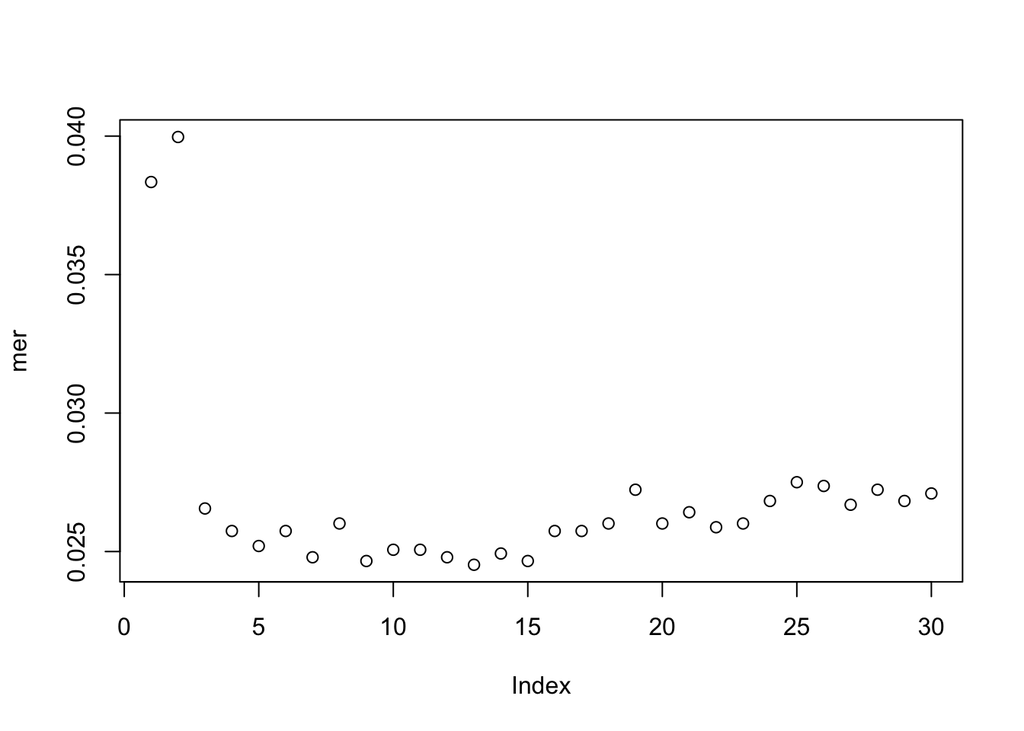

```r
# By running var and mean functions, we can see the predictors are not standarized to a mean of zero and standard deviation of one. Thus, standardization step does need.
X <- rbind(X.train,X.valid)
X.std <- scale(X)
X.train.std <- X.std[1:n.train,]
X.valid.std <- X.std[(n.train+1):(n.train+n.valid),]

library(class)
mer <- rep(NA, 30) # misclassification error rates based on leave-one-out cross-validation
set.seed(2014) # seed must be set because R randomly breaks ties
for (i in 1:30) mer[i] <- sum((Y.train-(c(knn.cv(train=X.train.std, cl=Y.train, k=i))-1))^2)/n.train
plot(mer)
```

```r
which.min(mer) # minimum occurs at k=13
```

```
## [1] 13
```

```r
set.seed(2014)
model.knn <- knn(train=X.train.std, test=X.train.std, cl=Y.train, k=13, prob=T)
predclass.knn <- c(model.knn)-1 # convert factor to numeric classes
predprob.knn <- attr(model.knn, "prob") # proportion of votes for winning class
post.train.knn <- predclass.knn*predprob.knn+(1-predclass.knn)*(1-predprob.knn) # n.train post probs of Y=1
Ghat.train.knn <- ifelse(post.train.knn > sort(post.train.knn, decreasing=T)[201],1,0) # classification rule
table(Ghat.train.knn,Y.train) # classification table
```

```
##               Y.train
## Ghat.train.knn    0    1
##              0 7091  103
##              1   93   94
```

```r
#              Y.train
#Ghat.train.knn    0    1
#             0 7091  103
#             1   93   94
sum(abs(Ghat.train.knn-Y.train))/n.train # training data classification error rate = (93+103)/7381 = 0.027
```

```
## [1] 0.02655467
```

```r
sum(Ghat.train.knn==1&Y.train==1)/sum(Y.train==1) # sensitivity = 94/(94+103) = 0.477
```

```
## [1] 0.4771574
```

```r
sum(Ghat.train.knn==0&Y.train==0)/sum(Y.train==0) # specificity = 7091/(7091+93)
```

```
## [1] 0.9870546
```

```r
# 0.987

# Suppose we had validation data as for previous examples
set.seed(2014)
model.knn <- knn(train=X.train.std, test=X.valid.std, cl=Y.train, k=13, prob=T)
predclass.knn <- c(model.knn)-1 # convert factor to numeric classes
predprob.knn <- attr(model.knn, "prob") # proportion of votes for winning class
post.valid.knn <- predclass.knn*predprob.knn+(1-predclass.knn)*(1-predprob.knn) # n.valid post probs of Y=1
Ghat.valid.knn <- ifelse(post.valid.knn > sort(post.valid.knn, decreasing=T)[201],1,0) # use same probability cutoff
table(Ghat.valid.knn,Y.valid) # classification table
```

```
##               Y.valid
## Ghat.valid.knn    0    1
##              0 1271   21
##              1   64   22
```

```r
#              Y.valid
#Ghat.valid.knn    0    1
#             0 1271   21
#             1   64   22
sum(abs(Ghat.valid.knn-Y.valid))/n.valid # classification error rate = (21+64)/1378 = 0.062
```

```
## [1] 0.0616836
```

```r
sum(Ghat.valid.knn==1&Y.valid==1)/sum(Y.valid==1) # sensitivity = 22/(21+22) = 0.512
```

```
## [1] 0.5116279
```

```r
sum(Ghat.valid.knn==0&Y.valid==0)/sum(Y.valid==0) # specificity = 1271/(1271+64) = 0.952
```

```
## [1] 0.9520599
```

#### Model e: Logistic regression generalized additive model (GAM)

```r
library(gam)
model.gam <- gam(Y ~ s(X1,df=5)+ s(X2,df=5)+s(X3,df=5)+s(X4,df=5)+s(X5,df=5), data.train, family=binomial)
summary(model.gam)
```

```
##
## Call: gam(formula = Y ~ s(X1, df = 5) + s(X2, df = 5) + s(X3, df = 5) +
##     s(X4, df = 5) + s(X5, df = 5), family = binomial, data = data.train)
## Deviance Residuals:
##      Min       1Q   Median       3Q      Max
## -0.98164 -0.21565 -0.13202 -0.09386  3.73839
##
## (Dispersion Parameter for binomial family taken to be 1)
##
##     Null Deviance: 1816.338 on 7380 degrees of freedom
## Residual Deviance: 1408.102 on 7355 degrees of freedom
## AIC: 1460.102
##
## Number of Local Scoring Iterations: 12
##
## Anova for Parametric Effects
##                 Df  Sum Sq Mean Sq F value    Pr(>F)
## s(X1, df = 5)    1    92.2  92.211 55.7125 9.352e-14 ***
## s(X2, df = 5)    1    60.5  60.484 36.5432 1.566e-09 ***
## s(X3, df = 5)    1    73.7  73.737 44.5508 2.659e-11 ***
## s(X4, df = 5)    1     0.0   0.014  0.0085    0.9264
## s(X5, df = 5)    1     3.3   3.260  1.9695    0.1605
## Residuals     7355 12173.5   1.655
## ---
## Signif. codes:  0 '***' 0.001 '**' 0.01 '*' 0.05 '.' 0.1 ' ' 1
##
## Anova for Nonparametric Effects
##               Npar Df Npar Chisq    P(Chi)
## (Intercept)
## s(X1, df = 5)       4     18.628 0.0009296 ***
## s(X2, df = 5)       4     25.319 4.339e-05 ***
## s(X3, df = 5)       4     36.109 2.749e-07 ***
## s(X4, df = 5)       4     11.332 0.0230774 *
## s(X5, df = 5)       4     10.367 0.0346830 *
## ---
## Signif. codes:  0 '***' 0.001 '**' 0.01 '*' 0.05 '.' 0.1 ' ' 1
```

```r
#Call: gam(formula = Y ~ s(X1, df = 5) + s(X2, df = 5) + s(X3, df = 5) +
#    s(X4, df = 5) + s(X5, df = 5), family = binomial, data = data.train)
#Deviance Residuals:
#     Min       1Q   Median       3Q      Max
#-0.98164 -0.21565 -0.13202 -0.09386  3.73839
#
#(Dispersion Parameter for binomial family taken to be 1)
#
#    Null Deviance: 1816.338 on 7380 degrees of freedom
#Residual Deviance: 1408.102 on 7355 degrees of freedom
#AIC: 1460.102
#
#Number of Local Scoring Iterations: 12

#Anova for Parametric Effects
#                Df  Sum Sq Mean Sq F value    Pr(>F)
#s(X1, df = 5)    1    92.2  92.211 55.7125 9.352e-14 ***
#s(X2, df = 5)    1    60.5  60.484 36.5432 1.566e-09 ***
#s(X3, df = 5)    1    73.7  73.737 44.5508 2.659e-11 ***
#s(X4, df = 5)    1     0.0   0.014  0.0085    0.9264
#s(X5, df = 5)    1     3.3   3.260  1.9695    0.1605
#Residuals     7355 12173.5   1.655
#---
#Signif. codes:  0 ‘***’ 0.001 ‘**’ 0.01 ‘*’ 0.05 ‘.’ 0.1 ‘ ’ 1
#
#Anova for Nonparametric Effects
#              Npar Df Npar Chisq    P(Chi)
#(Intercept)
#s(X1, df = 5)       4     18.628 0.0009296 ***
#s(X2, df = 5)       4     25.319 4.339e-05 ***
#s(X3, df = 5)       4     36.109 2.749e-07 ***
#s(X4, df = 5)       4     11.332 0.0230774 *
#s(X5, df = 5)       4     10.367 0.0346830 *
#---
#Signif. codes: 0 ‘***’ 0.001 ‘**’ 0.01 ‘*’ 0.05 ‘.’ 0.1 ‘ ’ 1

post.train.gam <- model.gam$fitted.values # n.train posterior probabilities of Y=1
Ghat.train.gam <- ifelse(post.train.gam > sort(post.train.gam, decreasing=T)[201],1,0) # classification rule
table(Ghat.train.gam,Y.train) # classification table
```

```
##               Y.train
## Ghat.train.gam    0    1
##              0 7071  110
##              1  113   87
```

```r
#              Y.train
#Ghat.train.gam    0    1
#             0 7071  110
#             1  113   87
sum(abs(Ghat.train.gam-Y.train))/n.train # training data classification error rate = (110+113)/7381 = 0.030
```

```
## [1] 0.03021271
```

```r
sum(Ghat.train.gam==1&Y.train==1)/sum(Y.train==1) # sensitivity = 87/(110+87) = 0.442
```

```
## [1] 0.4416244
```

```r
sum(Ghat.train.gam==0&Y.train==0)/sum(Y.train==0) # specificity = 7071/(7071+113) = 0.984
```

```
## [1] 0.9842706
```

```r
# Suppose we had validation data as for other examples
post.valid.gam <- predict(model.gam, data.valid, type="response") # n.valid post probs
Ghat.valid.gam <- ifelse(post.valid.gam > sort(post.valid.gam, decreasing=T)[201],1,0) # use same probability cutoff
table(Ghat.valid.gam,Y.valid) # classification table
```

```
##               Y.valid
## Ghat.valid.gam    0    1
##              0 1160   18
##              1  175   25
```

```r
#              Y.valid
#Ghat.valid.gam    0    1
#             0 1160   18
#             1  175   25
sum(abs(Ghat.valid.gam-Y.valid))/n.valid # classification error rate = (175+18)/1378 = 0.140
```

```
## [1] 0.1400581
```

```r
sum(Ghat.valid.gam==1&Y.valid==1)/sum(Y.valid==1) # sensitivity = 25/(25+18) = 0.581
```

```
## [1] 0.5813953
```

```r
sum(Ghat.valid.gam==0&Y.valid==0)/sum(Y.valid==0) # specificity = 1160/(1160+175) = 0.869
```

```
## [1] 0.8689139
```